# **Chapter 06 字串(Strings)**

## **字串的資料型態**

- 字串是一連串的字(character)
- 字串需要用引號包住，像是"Hello"或'Hello'

```python
str1 = 'Hello'
str2 = "there"
```

- 對於字串來說，兩個字串用+號連接，表示連接兩個字串的內容

```python
bob = str1 + str2
print(bob)
```

```
Hellothere
```

- 當字串就算是數字，它仍然是個字串

```python
str3 = '123'
str3 = str3 + 1
```

```
---------------------------------------------------------------------------
TypeError                                 Traceback (most recent call last)
<ipython-input-3-a3c2e55be021> in <module>()
      1 str3 = '123'
----> 2 str3 = str3 + 1

TypeError: must be str, not int
```

- 我們可以使用內建函數int()或float()將字串轉為數字

```python
x = int(str3) + 1
print(x)
```

```
124
```

## **字串的讀取及轉換**

- 我們將輸入的資料以字串的型態讀入，再接著剖析或轉換資料，變成我們要使用的型態
- 這樣的做法可以給我們對於錯誤的狀況，或是使用者輸入錯誤的內容有更多的控制權
- 輸入的數字必須得從字串進行轉換

```python
name = input('Enter:')
print(name)
```

```
Enter:Chunk
Chunk
```

```python
apple = input('Enter:')
x = apple - 10
print(x)
```

```
Enter:100
```

```
---------------------------------------------------------------------------
TypeError                                 Traceback (most recent call last)
<ipython-input-2-77b8da56555e> in <module>()
      1 apple = input('Enter:')
----> 2 x = apple - 10
      3 print(x)

TypeError: unsupported operand type(s) for -: 'str' and 'int'
```

```python
apple = input('Enter:')
x = int(apple) - 10
print(x)
```

```
Enter:100
90
```

## **看看字串裡面**

- 我們可以使用中括號加上索引值，取得字串中的任意一個字
- 索引值一定要是從0開始的整數
- 索引值可以是一個計算得出結果的表達式

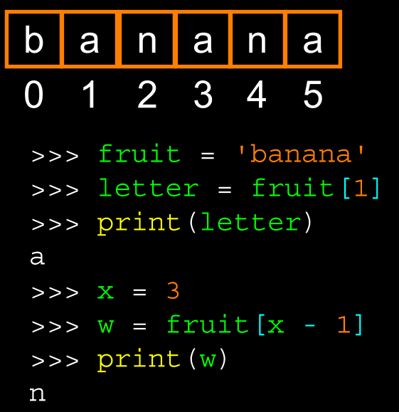

```python
fruit = 'banana'
letter = fruit[1]
print(letter)

x = 3
w = fruit[x - 1]
print(w)
```

```
a
n
```

## **找尋太遠的字**

- 如果索引值超越字串的長度，你將會收到Python的錯誤通知
- 所以在使用索引值時要特別小心

```python
zot = 'abc'
print(zot[5])
```

```
---------------------------------------------------------------------------
IndexError                                Traceback (most recent call last)
<ipython-input-5-6acb855f1a9c> in <module>()
      1 zot = 'abc'
----> 2 print(zot[5])

IndexError: string index out of range
```

## **字串有長度**

- 使用內建函數len()可以取得字串的長度

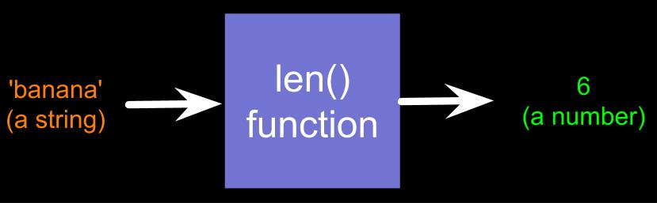

```python
fruit = 'banana'
print(len(fruit))
```

```
6
```

## **使用迴圈尋訪字串(1)**

- 使用while以及迭代變數再加上len()函數，我們可以建立一個可以尋訪字串中每一個字的迴圈

```python
fruit = 'banana'
index = 0
while index < len(fruit):
    letter = fruit[index]
    print(index, letter)
    index = index + 1
```

```
0 b
1 a
2 n
3 a
4 n
5 a
```

## **使用迴圈尋訪字串(2)**

- 使用for迴圈，表達方式會更簡潔，因為迭代變數完全由for迴圈來控制

```python
fruit = 'banana'
index = 0
for letter in fruit:
    print(index, letter)
    index = index + 1
```

```
0 b
1 a
2 n
3 a
4 n
5 a
```

## **迴圈與計數**

- 這是一個簡單的回圈，會去尋訪字串中每一個字並且計算a出現的次數

```python
word = 'banana'
count = 0
for letter in word:
    if letter == 'a':
        count = count + 1
print(count)
```

```
3
```

## **更細的來看「in」**

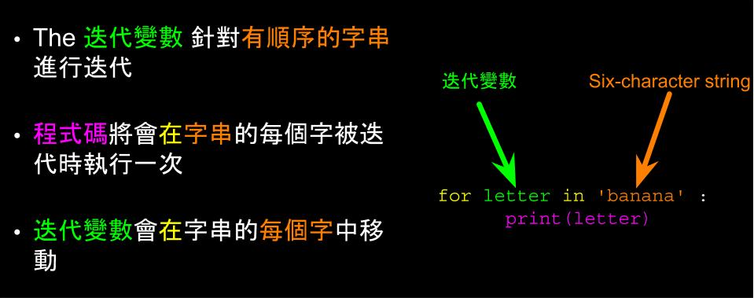

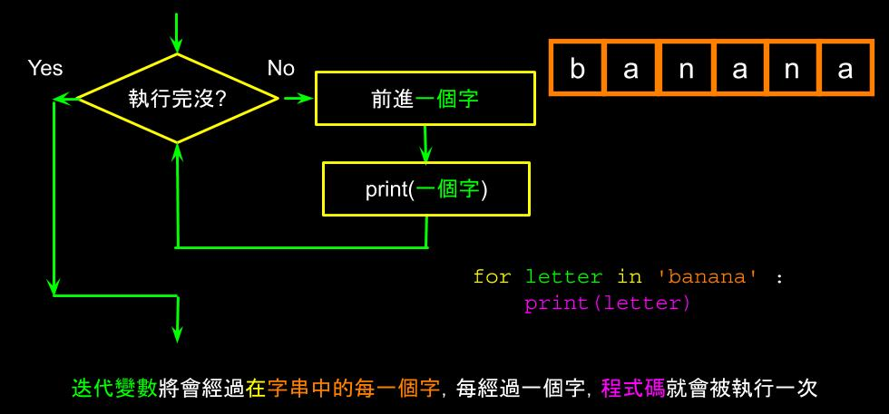

## **更多字串的操作**

### 切割字串 (Slicing String)

- 我們可以使用冒號運算子查看字串的任何連續部分
- 冒號運算子的第二個數字是字串的結束位置，但不包含該位置
- 如果冒號運算子的第二個數字大於字串結束的位置，則最長就只到字串的結尾

[figure not shown]

```python
s = 'Monty Python'
print(s[0:4])
print(s[6:7])
print(s[6:20])
```

```
Mont
P
Python
```

- 如果讓冒號運算子的第一個數字或第二個數字為空(不寫任何數字)，第一個數字不寫就預設為字串的開頭、第二個數字不寫就預設為字串的結尾

[figure not shown]

```python
s = 'Monty Python'
print(s[:2])
print(s[8:])
print(s[:])
```

```
Mo
thon
Monty Python
```

### 字串連接 (String Concatenation)

- 對兩個字串使用+符號時，表示連接兩個字串

```python
a = 'Hello'
b = a + 'There'
print(b)

c = a + ' ' + 'There'
print(c)
```

```
HelloThere
Hello There
```

### 使用in當作字串的邏輯運算子

- in這個字除了使用在for迴圈，也可以使用在檢查某一段字串是不是「有包含(in)」特定的字串在其中
- 所以in的檢查會表示True或False，所以可以用在if的判斷式中

```python
fruit = 'banana'
print('n' in fruit)
print('m' in fruit)
print('nan' in fruit)
if 'a' in fruit:
    print('Found it!')
```

```
True
False
True
Found it!
```

### 字串比較

```python
# 試著改變word的內容試看看
word = 'banana'
# word = 'bZffee'
if word == 'banana':
    print('All right, bananas.')

# A > Z, Z > a, a > z
if word < 'banana':
    print('Your word,' + word + ', comes before banana')
elif word > 'banana':
    print('Your word,' + word + ', comes after banana')
else:
    print('All right, bananas.')
```

```
All right, bananas.
All right, bananas.
```

### 其他操作字串功能

- Python在字串中有許多字串內建函數

```python
greet = 'Hello Bob'
zap = greet.lower()
print(zap)
print(greet)
print('Hi There'.lower())
```

```
hello bob
Hello Bob
hi there
```

- 常用的一些字串內建函數
  - str.capitalize()
  - str.center(width[, fillchar])
  - str.endswith(suffix[, start[, end]])
  - str.find(sub[, start[, end]])
  - str.lstrip([chars])
  - str.replace(old, new[, count])
  - str.lower()
  - str.rstrip([char])
  - str.strip([char])
  - str.upper()

#### 找尋字串 find()

- 我們使用find()來尋找某些特定的文字/字串在其他字串中的位置
- find()會回傳字串中首先找到的位置
- 如果找不到，find()會回傳-1
- **要記得，字串開始的位置是0**

```python
fruit = 'banana'
pos = fruit.find('na')
print(pos)

aa = fruit.find('z')
print(aa)
```

```
2
-1
```

#### 所有字轉為大小寫 upper()/lower()

- 你可以讓字串轉為完全大寫或小寫
- 我們多半會把文字轉為小寫在進行find()，這樣不管文字大小寫都可以正確找到

```python
greet = 'Hello Bob'
nnn = greet.upper()
print(nnn)

www = greet.lower()
print(www)
```

[output not shown]

#### 替換文字 replace()

- replace()可以尋找特定文字並替換掉
- replace()會將所有找到的特定文字**全部**都替換掉

```python
greet = 'Hello Bob'
nstr = greet.replace('Bob', 'Jane')
print(nstr)

nstr = greet.replace('o', 'X')
print(nstr)
```

```
Hello Jane
HellX BXb
```

#### 去除空白 strip()

- 我們可以使用以下方法去除字串開頭結尾的空白
- lstrip()移除字串左方的空白
- rstrip()移除字串右方的空白
- strip()移除左方與右方的空白

```python
greet = '   Hello Bob   '
print('---' + greet.lstrip() + '---')

print('---' + greet.rstrip() + '---')

print('---' + greet.strip() + '---')
```

```
---Hello Bob   ---
---   Hello Bob---
---Hello Bob---
```

#### 檢查字串開頭

```python
line = 'Please have a nice day'
print(line.startswith('Please'))
print(line.startswith('p'))
```

```
True
False
```

### 從字串中剖析並找出特定資訊

```
From stephen.marquard@utc.ac.za Sat Jan  5 09:14:16 2008
                     ↑        ↑
                     21       31
```

```python
data = 'From stephen.marquard@utc.ac.za Sat Jan  5 09:14:16 2008'
atpos = data.find('@')
print(atpos)

sppos = data.find(' ', atpos)
print(sppos)

host = data[atpos+1 : sppos]
print(host)
```

```
21
31
utc.ac.za
```

## **總結**

- String type
- Read / Convert
- Indexing strings []
- Slicing strings [2:4]
- Looping through strings with for and while
- Concatenation strings with +
- String operations
- String Comparisons
- String library
  - Searching in strings
  - Replacing text
  - Stripping white space

## **作業**

- 寫一段程式碼，使用find()與字串切割(slice)取出以下字串最後的數字，並將該數字轉為浮點數印在畫面上
  - X-DSPAM- Confidence: 0.8475

# Acknowledgements / Contributions

Python For Everyone

- These slides are Copyright 2010- Charles R. Severance (www.dr-chuck.com) of the University of Michigan School of Information and made available under a Creative Commons Attribution 4.0 License. Please maintain this last slide in all copies of the document to comply with the attribution requirements of the license. If you make a change, feel free to add your name and organization to the list of contributors on this page as you republish the materials.
- Initial Development: Charles Severance, University of Michigan School of Information